# PDS-PYTHON

## **PROCESAMIENTO DIGITAL DE SEÑALES USANDO JUPYTER-LAB**

*1 Señales y sistemas*

> 1.1 Definición y tipos de señales  
> 1.2 Señales discretas básicas  
> 1.3 Sistemas discretos y sus caracterı́sticas  
> 1.4 Sistemas lineales e invariantes en el tiempo  
> 1.5 Correlación y autocorrelación

*2 Representación en el dominio de la frecuencia*

> 2.1 Respuesta de un sistema LIT a una exponencial compleja  
> 2.2 Transformada de Fourier  
> 2.3 Propiedades de la transformada de Fourier  
> 2.4 Filtros FIR

*3 Transformada de Laplace e Inversa*

*4 Transformada discreta de Fourier*

> 4.1 Periodicidad en tiempo discreto  
> 4.2 Transformada discreta de Fourier  
> 4.3 Convolución circular  
> 4.4 Propiedades de la TDF  
> 4.5 Transformada rápida de Fourier

*5 Muestreo y reconstrucción de señales*

> 5.1 Muestreo de señales en tiempo contı́nuo  
> 5.2 Teorema de muestreo de Nyquist  
> 5.3 Reconstrucción de señales de banda limitada

*6 Transformada Z*

> 6.1 Definición  
> 6.2 Región de convergencia  
> 6.3 Transformada Z racional  
> 6.4 Propiedades de la transformada Z  
> 5.5 Representación de sistemas LIT en el dominio Z

*7 Filtros digitales*

> 7.1 Principio de incertidumbre de Heisenberg  
> 7.2 Consideraciones para el diseño de filtros  
> 7.3 Diseño de filtros FIR mediante enventanado  
> 7.4 Diseño de filtros IIR

*8 Biblografía*  
$\qquad$7.1  
$\qquad$7.2

*1 Señales y sistemas*

> 1.1 Definición y tipos de señales

## **-----------------------------------------------**

*1 Señales y sistemas*

> 1.1 Definición y tipos de señales  
> Podemos definir a una señal como aquella que tiene una magnitud (escarlar vectorial) que varía en función de otra magnitud o magnitudes como puede ser el tiempo, la distancia, etc. Éstas se pueden clasificar en señales determinísticas y aleatorias. Como ejemplo de señales podemos mencionar las acústicas, el electrocardiograma, ondas sísticas, etc. Las señales del mundo natural son continuas en el tiempo y las señales discretas son valores secuenciales en cada instante de tiempo. Tener en cuenta que las señales discretas tienen valor indeterminado entre cada muestra, no confundir con ponerle valor 0. Por ejemplo la temperatura del ambiente es una señal continua, y el valor de depreciación de una casa a lo largo del tiempo es discreta, porque sólos se contemplan valores por cada año.

```python
import numpy as np
import matplotlib.pyplot as plt
import scipy as sp
```

#### **Tipos de señales a estudiar**

##### *Señal paso unitario = Unit step*

$ u_{s}(t) = \left\{ \begin{array}\\ 1 & \mbox{for } \ t \geq 0 \\ 0 & \mbox{for } \ t <0 \end{array} \right. $

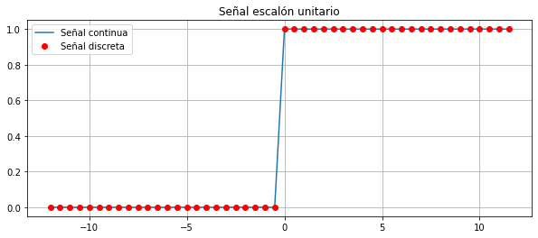

```python
t = np.arange(-12,12, 0.5)
ceros = np.zeros(int(len(t)/2))
ones = np.ones(int(len(t)/2))
step = []
step = np.append(ceros, ones)
plt.figure(figsize=(10,4))
plt.plot(t, step, t, step, 'ro')
plt.legend(['Señal continua', 'Señal discreta'])
plt.title('Señal escalón unitario')
plt.grid ('on')
```

```python
class Signal:
    def __init__(self, n, k):
        self.n = n
        self.k = k
    def step(self):
        if type(self.n) !=int and type(self.k) !=int and int(self.n) == 0:
            return "Ingrese (n, k) como entero"
        else:
            print ("Hola, n = " + str(self.n) + " y k = " + str(self.k))
```

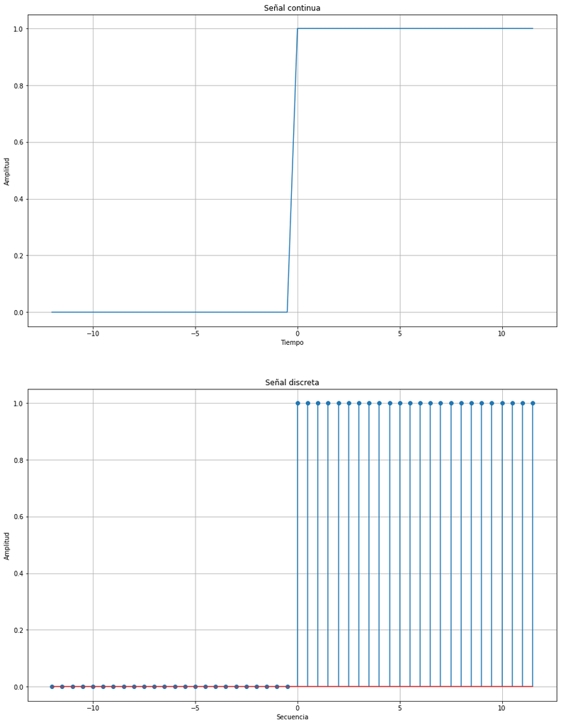

```python
plt.figure(figsize=(15,20))
plt.subplot(2,1,1)
plt.plot(t,step)
plt.title('Señal continua')
plt.xlabel('Tiempo')
plt.ylabel('Amplitud')
plt.grid('on')
plt.subplot(2,1,2)
plt.stem(t,step, use_line_collection=True)
plt.title('Señal discreta')
plt.xlabel('Secuencia')
plt.ylabel('Amplitud')
plt.grid('on')
```

[output not shown]

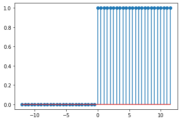

```python
# Tipos de Señales a estudiar
step = []
step = np.append(ceros, [1]*(int(len(t)/2)))
plt.stem(t, step, use_line_collection=True)
```

[output not shown]

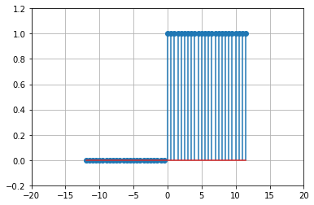

```python
plt.stem(t,step, use_line_collection=True)
plt.axis([-20,20,-0.2, 1.2])
plt.grid('on')
len(step), len(t)
```

[output not shown]

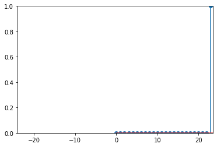

```python
imp=[]
ceros = np.zeros(int((len(t)-1)/2))
imp = np.append(ceros, 1)
imp = np.append(imp, ceros)
plt.stem(imp, use_line_collection=True)
plt.axis([-int(len(t)/2), int(len(t)-1)/2, 0, 1])
```